# Rocket Retail — Cart-to-Purchase Conversion Analysis

Alexandre Leblanc

## 1. Business Question

The goal of this analysis is to understand **user purchase behavior at the item level**, specifically:

- How many items are **added to cart but never purchased**?
- How many items are **both carted and purchased**?
- Are there items that are **purchased without prior cart interaction**?

This analysis helps evaluate **conversion efficiency**, **drop-off after expressed intent**, and the presence of **direct-purchase behaviors or tracking limitations**.

## 2. Data Overview

The analysis is based on event-level retail data containing:

- `visitorid`
- `itemid`
- `first_cart_ts` (timestamp of the first add-to-cart event, if any)
- `purchase_ts` (timestamp of purchase event, if any)

Because multiple events can occur for the same visitor–item pair, event-level data was **collapsed to an item-level grain** prior to analysis.

## 2.1 Data Extraction (SQL)

The original Rocket Retail dataset is organized as a large event-level table containing multiple event types. To reduce noise and ensure correct analytical grain, I extracted only the **add-to-cart** and **transaction** events using SQL prior to analysis in R.

```r
SELECT visitorid,
       itemid,
       MIN(timestamp) AS first_cart_ts
FROM `rocket-retail-483319.rocket_retail.events`
WHERE event = 'addtocart'
GROUP BY visitorid, itemid;



SELECT visitorid,
       itemid,
       MIN(timestamp) AS purchase_ts
FROM `rocket-retail-483319.rocket_retail.events`
WHERE event = 'transaction'
GROUP BY visitorid, itemid;
```

This case was designed to demonstrate independent problem framing and SQL-based data preparation prior to analysis, rather than following a predefined question set.

## 3. Analytical Approach

Rather than counting raw events, I derived **state-level outcomes** for each `(visitorid, itemid)` pair.

Each pair is classified into one of three mutually exclusive states:

- **Carted Only** – item was added to cart but never purchased
- **Carted & Bought** – item was added to cart and later purchased
- **Bought Only** – item was purchased without a recorded cart event

This required: - grouping by visitor and item - collapsing multiple rows into a single outcome - explicit handling of missing values (`NA`) to ensure logical correctness

```r
library(ggplot2)
library(tidyverse)
library(dplyr)

add_to_cart <- read_csv("archive-2/bq-results-addtocart.csv")
bought <- read_csv("archive-2/bq-results-transaction.csv")

merged_carted_bought <- bind_rows(add_to_cart, bought)

carted_and_bought <- merged_carted_bought %>%
  group_by(visitorid, itemid) %>%
  summarise( has_cart = any(first_cart_ts != "NA"),
             has_buy = any(purchase_ts != "NA"),
             .groups = "drop") %>%
  filter(has_cart, has_buy)
```

## 4. Data Transformation (R)

```r
state <- merged_carted_bought %>%
     group_by(visitorid, itemid) %>%
     summarise(
         has_cart = any(first_cart_ts != "NA", na.rm = TRUE),
         has_bought = any(purchase_ts != "NA", na.rm = TRUE),
         state = case_when(
             has_cart & has_bought ~ "Carted & Bought",
             has_cart & !has_bought ~ "Carted Only",
             !has_cart & has_bought ~ "Bought Only"
         ),
         .groups = "drop"
     )


state_count <- state %>%
  count(state)

state_count <- state_count %>%
mutate(pct = n / sum(n))
```

## 5. Visualization

### Conversion States (Absolute Volume)

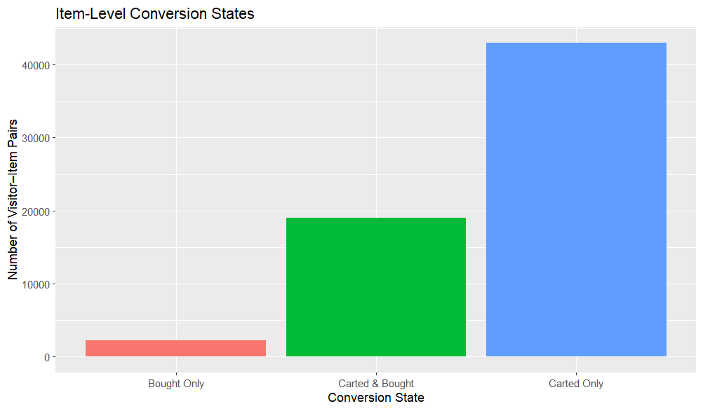

### Conversion States (Proportion of Total)

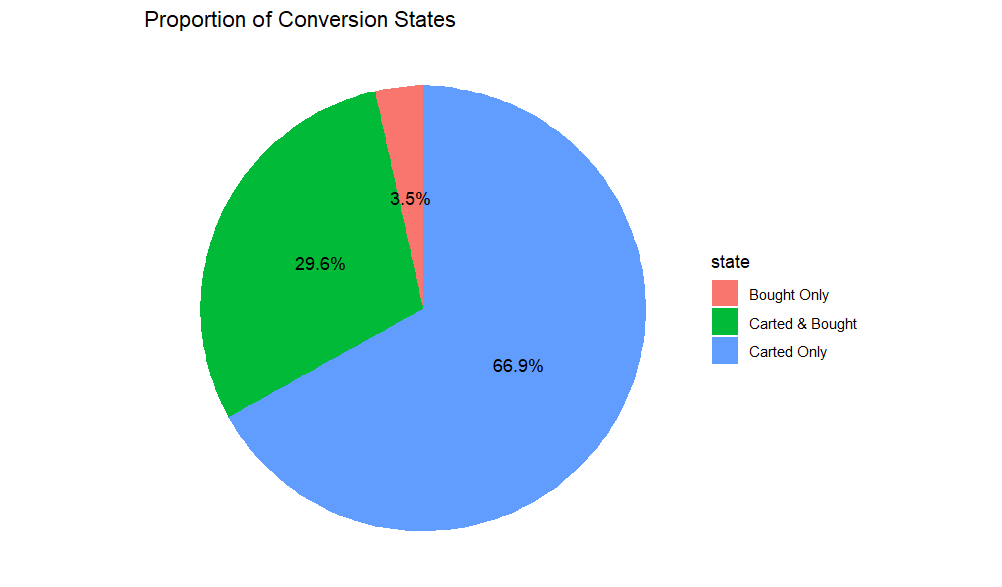

## 6. Act

### Recommendations

- **Reduce cart abandonment:** A large share of visitor–item pairs fall into the “Carted Only” state. This suggests meaningful drop-off after intent is expressed. Recommended next steps include testing checkout friction reductions (fewer steps, clearer shipping costs, guest checkout) and targeted reminders for carted items.
- **Investigate “Bought Only” behavior:** A smaller but non-zero portion of purchases occur without a recorded cart event. This may indicate direct-purchase flows (e.g., “Buy Now”), tracking gaps, or edge-case behavior. Confirming the underlying cause would improve funnel measurement accuracy.
- **Segment follow-up analysis:** In future work, conversion states can be broken down by time windows (e.g., cart-to-buy lag), product category, or user cohorts to identify where conversions succeed and where drop-off is concentrated.